# Risk Factor Analysis

## Outcome Variable

**Outcome Variable:** ever_swasted

## Predictor Variables

**Intervention Variable:** hhwealth_quart

**Adjustment Set:**

- arm
- sex
- W_mage
- meducyrs
- feducyrs
- W_gagebrth
- W_birthwt
- W_birthlen
- W_nchldlt5
- W_parity
- delta_W_mage
- delta_meducyrs
- delta_feducyrs
- delta_W_gagebrth
- delta_W_birthwt
- delta_W_birthlen
- delta_W_nchldlt5
- delta_W_parity

## Stratifying Variables

The analysis was stratified on these variable(s):

- agecat
- studyid
- country

## Data Summary

| agecat | studyid | country | hhwealth_quart | ever_swasted | n_cell | n |
| --- | --- | --- | --- | --- | --- | --- |
| 0-24 months | CMC-V-BCS-2002 | INDIA | Wealth Q4 | 0 | 86 | 373 |
| 0-24 months | CMC-V-BCS-2002 | INDIA | Wealth Q4 | 1 | 10 | 373 |
| 0-24 months | CMC-V-BCS-2002 | INDIA | Wealth Q1 | 0 | 66 | 373 |
| 0-24 months | CMC-V-BCS-2002 | INDIA | Wealth Q1 | 1 | 25 | 373 |
| 0-24 months | CMC-V-BCS-2002 | INDIA | Wealth Q2 | 0 | 60 | 373 |
| 0-24 months | CMC-V-BCS-2002 | INDIA | Wealth Q2 | 1 | 35 | 373 |
| 0-24 months | CMC-V-BCS-2002 | INDIA | Wealth Q3 | 0 | 69 | 373 |
| 0-24 months | CMC-V-BCS-2002 | INDIA | Wealth Q3 | 1 | 22 | 373 |
| 0-24 months | COHORTS | GUATEMALA | Wealth Q4 | 0 | 442 | 1263 |
| 0-24 months | COHORTS | GUATEMALA | Wealth Q4 | 1 | 34 | 1263 |
| 0-24 months | COHORTS | GUATEMALA | Wealth Q1 | 0 | 229 | 1263 |
| 0-24 months | COHORTS | GUATEMALA | Wealth Q1 | 1 | 15 | 1263 |
| 0-24 months | COHORTS | GUATEMALA | Wealth Q2 | 0 | 242 | 1263 |
| 0-24 months | COHORTS | GUATEMALA | Wealth Q2 | 1 | 16 | 1263 |
| 0-24 months | COHORTS | GUATEMALA | Wealth Q3 | 0 | 257 | 1263 |
| 0-24 months | COHORTS | GUATEMALA | Wealth Q3 | 1 | 28 | 1263 |
| 0-24 months | COHORTS | PHILIPPINES | Wealth Q4 | 0 | 743 | 3044 |
| 0-24 months | COHORTS | PHILIPPINES | Wealth Q4 | 1 | 97 | 3044 |
| 0-24 months | COHORTS | PHILIPPINES | Wealth Q1 | 0 | 590 | 3044 |
| 0-24 months | COHORTS | PHILIPPINES | Wealth Q1 | 1 | 91 | 3044 |
| 0-24 months | COHORTS | PHILIPPINES | Wealth Q2 | 0 | 473 | 3044 |
| 0-24 months | COHORTS | PHILIPPINES | Wealth Q2 | 1 | 67 | 3044 |
| 0-24 months | COHORTS | PHILIPPINES | Wealth Q3 | 0 | 856 | 3044 |
| 0-24 months | COHORTS | PHILIPPINES | Wealth Q3 | 1 | 127 | 3044 |
| 0-24 months | CONTENT | PERU | Wealth Q4 | 0 | 51 | 215 |
| 0-24 months | CONTENT | PERU | Wealth Q4 | 1 | 1 | 215 |
| 0-24 months | CONTENT | PERU | Wealth Q1 | 0 | 59 | 215 |
| 0-24 months | CONTENT | PERU | Wealth Q1 | 1 | 0 | 215 |
| 0-24 months | CONTENT | PERU | Wealth Q2 | 0 | 52 | 215 |
| 0-24 months | CONTENT | PERU | Wealth Q2 | 1 | 0 | 215 |

[output cut: 402 more lines]

The following strata were considered:

- agecat: 0-24 months, studyid: CMC-V-BCS-2002, country: INDIA
- agecat: 0-24 months, studyid: COHORTS, country: GUATEMALA
- agecat: 0-24 months, studyid: COHORTS, country: PHILIPPINES
- agecat: 0-24 months, studyid: CONTENT, country: PERU
- agecat: 0-24 months, studyid: GMS-Nepal, country: NEPAL
- agecat: 0-24 months, studyid: IRC, country: INDIA
- agecat: 0-24 months, studyid: JiVitA-3, country: BANGLADESH
- agecat: 0-24 months, studyid: JiVitA-4, country: BANGLADESH
- agecat: 0-24 months, studyid: LCNI-5, country: MALAWI
- agecat: 0-24 months, studyid: MAL-ED, country: BANGLADESH
- agecat: 0-24 months, studyid: MAL-ED, country: BRAZIL
- agecat: 0-24 months, studyid: MAL-ED, country: INDIA
- agecat: 0-24 months, studyid: MAL-ED, country: NEPAL
- agecat: 0-24 months, studyid: MAL-ED, country: PERU
- agecat: 0-24 months, studyid: MAL-ED, country: SOUTH AFRICA
- agecat: 0-24 months, studyid: MAL-ED, country: TANZANIA, UNITED REPUBLIC OF
- agecat: 0-24 months, studyid: PROVIDE, country: BANGLADESH
- agecat: 0-24 months, studyid: TanzaniaChild2, country: TANZANIA, UNITED REPUBLIC OF
- agecat: 0-6 months, studyid: CMC-V-BCS-2002, country: INDIA
- agecat: 0-6 months, studyid: COHORTS, country: GUATEMALA
- agecat: 0-6 months, studyid: COHORTS, country: PHILIPPINES
- agecat: 0-6 months, studyid: CONTENT, country: PERU
- agecat: 0-6 months, studyid: GMS-Nepal, country: NEPAL
- agecat: 0-6 months, studyid: IRC, country: INDIA
- agecat: 0-6 months, studyid: JiVitA-3, country: BANGLADESH
- agecat: 0-6 months, studyid: JiVitA-4, country: BANGLADESH
- agecat: 0-6 months, studyid: LCNI-5, country: MALAWI
- agecat: 0-6 months, studyid: MAL-ED, country: BANGLADESH
- agecat: 0-6 months, studyid: MAL-ED, country: BRAZIL
- agecat: 0-6 months, studyid: MAL-ED, country: INDIA
- agecat: 0-6 months, studyid: MAL-ED, country: NEPAL
- agecat: 0-6 months, studyid: MAL-ED, country: PERU
- agecat: 0-6 months, studyid: MAL-ED, country: SOUTH AFRICA
- agecat: 0-6 months, studyid: MAL-ED, country: TANZANIA, UNITED REPUBLIC OF
- agecat: 0-6 months, studyid: PROVIDE, country: BANGLADESH
- agecat: 0-6 months, studyid: TanzaniaChild2, country: TANZANIA, UNITED REPUBLIC OF
- agecat: 6-24 months, studyid: CMC-V-BCS-2002, country: INDIA
- agecat: 6-24 months, studyid: COHORTS, country: GUATEMALA
- agecat: 6-24 months, studyid: COHORTS, country: PHILIPPINES
- agecat: 6-24 months, studyid: CONTENT, country: PERU
- agecat: 6-24 months, studyid: GMS-Nepal, country: NEPAL
- agecat: 6-24 months, studyid: IRC, country: INDIA
- agecat: 6-24 months, studyid: JiVitA-3, country: BANGLADESH
- agecat: 6-24 months, studyid: JiVitA-4, country: BANGLADESH
- agecat: 6-24 months, studyid: LCNI-5, country: MALAWI
- agecat: 6-24 months, studyid: MAL-ED, country: BANGLADESH
- agecat: 6-24 months, studyid: MAL-ED, country: BRAZIL
- agecat: 6-24 months, studyid: MAL-ED, country: INDIA
- agecat: 6-24 months, studyid: MAL-ED, country: NEPAL
- agecat: 6-24 months, studyid: MAL-ED, country: PERU
- agecat: 6-24 months, studyid: MAL-ED, country: SOUTH AFRICA
- agecat: 6-24 months, studyid: MAL-ED, country: TANZANIA, UNITED REPUBLIC OF
- agecat: 6-24 months, studyid: PROVIDE, country: BANGLADESH
- agecat: 6-24 months, studyid: TanzaniaChild2, country: TANZANIA, UNITED REPUBLIC OF

### Dropped Strata

Some strata were dropped due to rare outcomes:

- agecat: 0-24 months, studyid: CONTENT, country: PERU
- agecat: 0-24 months, studyid: LCNI-5, country: MALAWI
- agecat: 0-24 months, studyid: MAL-ED, country: BANGLADESH
- agecat: 0-24 months, studyid: MAL-ED, country: BRAZIL
- agecat: 0-24 months, studyid: MAL-ED, country: INDIA
- agecat: 0-24 months, studyid: MAL-ED, country: NEPAL
- agecat: 0-24 months, studyid: MAL-ED, country: PERU
- agecat: 0-24 months, studyid: MAL-ED, country: SOUTH AFRICA
- agecat: 0-24 months, studyid: MAL-ED, country: TANZANIA, UNITED REPUBLIC OF
- agecat: 0-6 months, studyid: CONTENT, country: PERU
- agecat: 0-6 months, studyid: LCNI-5, country: MALAWI
- agecat: 0-6 months, studyid: MAL-ED, country: BANGLADESH
- agecat: 0-6 months, studyid: MAL-ED, country: BRAZIL
- agecat: 0-6 months, studyid: MAL-ED, country: INDIA
- agecat: 0-6 months, studyid: MAL-ED, country: NEPAL
- agecat: 0-6 months, studyid: MAL-ED, country: PERU
- agecat: 0-6 months, studyid: MAL-ED, country: SOUTH AFRICA
- agecat: 0-6 months, studyid: MAL-ED, country: TANZANIA, UNITED REPUBLIC OF
- agecat: 0-6 months, studyid: PROVIDE, country: BANGLADESH
- agecat: 6-24 months, studyid: CMC-V-BCS-2002, country: INDIA
- agecat: 6-24 months, studyid: COHORTS, country: GUATEMALA
- agecat: 6-24 months, studyid: CONTENT, country: PERU
- agecat: 6-24 months, studyid: LCNI-5, country: MALAWI
- agecat: 6-24 months, studyid: MAL-ED, country: BANGLADESH
- agecat: 6-24 months, studyid: MAL-ED, country: BRAZIL
- agecat: 6-24 months, studyid: MAL-ED, country: INDIA
- agecat: 6-24 months, studyid: MAL-ED, country: NEPAL
- agecat: 6-24 months, studyid: MAL-ED, country: PERU
- agecat: 6-24 months, studyid: MAL-ED, country: SOUTH AFRICA
- agecat: 6-24 months, studyid: MAL-ED, country: TANZANIA, UNITED REPUBLIC OF
- agecat: 6-24 months, studyid: PROVIDE, country: BANGLADESH

## Methods Detail

We’re interested in the causal parameters $E[Y_a]$ for all values of $a \in \mathcal{A}$. These parameters represent the mean outcome if, possibly contrary to fact, we intervened to set all units to have $A=a$. Under the randomization and positivity assumptions, these are identified by the statistical parameters $\psi_a=E_W[E_{Y|A,W}(Y|A=a,W)]$. In addition, we’re interested in the mean of $Y$, $E[Y]$ under no intervention (the observed mean). We will estimate these parameters by using SuperLearner to fit the relevant likelihood factors – $E_{Y|A,W}(Y|A=a,W)$ and $p(A=a|W)$, and then updating our likelihood fit using a joint TMLE.

For unadjusted analyses ($W=\{\}$), initial likelihoods were estimated using Lrnr_glm to estimate the simple $E(Y|A)$ and Lrnr_mean to estimate $p(A)$. For adjusted analyses, a small library containing Lrnr_glmnet, Lrnr_xgboost, and Lrnr_mean was used.

Having estimated these parameters, we will then use the delta method to estimate relative risks and attributable risks relative to a prespecified baseline level of $A$.

# Results Detail

## Results Plots

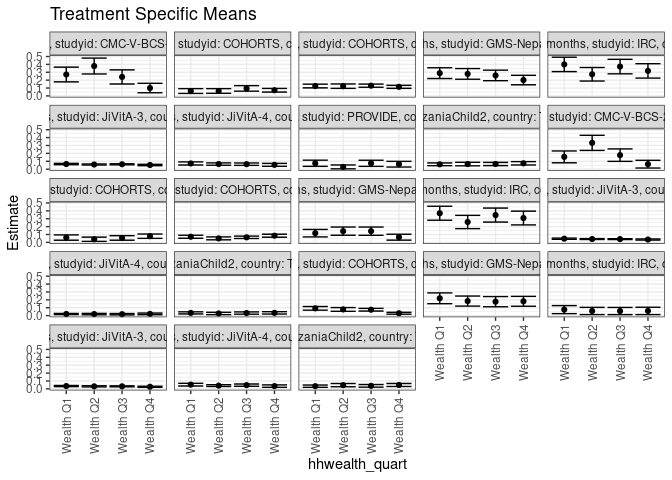

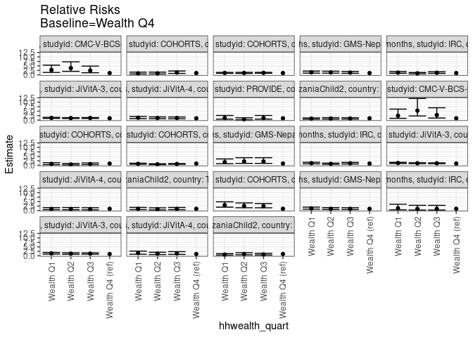

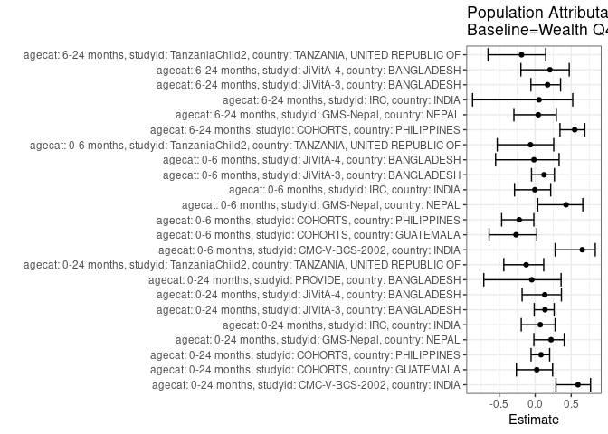

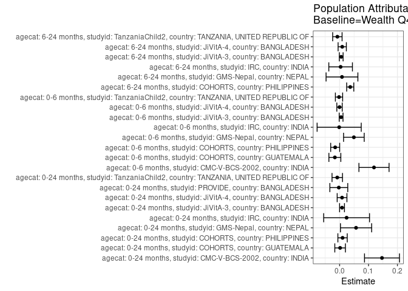

## Results Table

### Parameter: TSM

| agecat | studyid | country | intervention_level | baseline_level | estimate | ci_lower | ci_upper |
| --- | --- | --- | --- | --- | --- | --- | --- |
| 0-24 months | CMC-V-BCS-2002 | INDIA | Wealth Q4 | NA | 0.1000932 | 0.0400095 | 0.1601768 |
| 0-24 months | CMC-V-BCS-2002 | INDIA | Wealth Q1 | NA | 0.2717010 | 0.1782976 | 0.3651045 |
| 0-24 months | CMC-V-BCS-2002 | INDIA | Wealth Q2 | NA | 0.3788401 | 0.2781488 | 0.4795314 |
| 0-24 months | CMC-V-BCS-2002 | INDIA | Wealth Q3 | NA | 0.2407995 | 0.1512301 | 0.3303688 |
| 0-24 months | COHORTS | GUATEMALA | Wealth Q4 | NA | 0.0720043 | 0.0489693 | 0.0950392 |
| 0-24 months | COHORTS | GUATEMALA | Wealth Q1 | NA | 0.0620001 | 0.0317126 | 0.0922876 |
| 0-24 months | COHORTS | GUATEMALA | Wealth Q2 | NA | 0.0627658 | 0.0331418 | 0.0923897 |
| 0-24 months | COHORTS | GUATEMALA | Wealth Q3 | NA | 0.0953345 | 0.0603484 | 0.1303207 |
| 0-24 months | COHORTS | PHILIPPINES | Wealth Q4 | NA | 0.1153619 | 0.0963529 | 0.1343709 |
| 0-24 months | COHORTS | PHILIPPINES | Wealth Q1 | NA | 0.1256257 | 0.1021570 | 0.1490943 |
| 0-24 months | COHORTS | PHILIPPINES | Wealth Q2 | NA | 0.1236631 | 0.0956059 | 0.1517204 |
| 0-24 months | COHORTS | PHILIPPINES | Wealth Q3 | NA | 0.1299101 | 0.1099707 | 0.1498496 |
| 0-24 months | GMS-Nepal | NEPAL | Wealth Q4 | NA | 0.2012098 | 0.1409444 | 0.2614752 |
| 0-24 months | GMS-Nepal | NEPAL | Wealth Q1 | NA | 0.2887342 | 0.2205412 | 0.3569273 |
| 0-24 months | GMS-Nepal | NEPAL | Wealth Q2 | NA | 0.2791823 | 0.2117556 | 0.3466090 |
| 0-24 months | GMS-Nepal | NEPAL | Wealth Q3 | NA | 0.2596495 | 0.1929768 | 0.3263223 |
| 0-24 months | IRC | INDIA | Wealth Q4 | NA | 0.3173503 | 0.2260818 | 0.4086188 |
| 0-24 months | IRC | INDIA | Wealth Q1 | NA | 0.3995356 | 0.3083543 | 0.4907169 |
| 0-24 months | IRC | INDIA | Wealth Q2 | NA | 0.2746479 | 0.1888584 | 0.3604374 |
| 0-24 months | IRC | INDIA | Wealth Q3 | NA | 0.3720624 | 0.2798714 | 0.4642534 |
| 0-24 months | JiVitA-3 | BANGLADESH | Wealth Q4 | NA | 0.0527471 | 0.0437343 | 0.0617600 |
| 0-24 months | JiVitA-3 | BANGLADESH | Wealth Q1 | NA | 0.0647712 | 0.0565407 | 0.0730017 |
| 0-24 months | JiVitA-3 | BANGLADESH | Wealth Q2 | NA | 0.0588642 | 0.0521173 | 0.0656110 |
| 0-24 months | JiVitA-3 | BANGLADESH | Wealth Q3 | NA | 0.0619577 | 0.0553412 | 0.0685742 |
| 0-24 months | JiVitA-4 | BANGLADESH | Wealth Q4 | NA | 0.0546283 | 0.0361994 | 0.0730573 |
| 0-24 months | JiVitA-4 | BANGLADESH | Wealth Q1 | NA | 0.0723275 | 0.0526311 | 0.0920240 |
| 0-24 months | JiVitA-4 | BANGLADESH | Wealth Q2 | NA | 0.0646250 | 0.0498346 | 0.0794154 |
| 0-24 months | JiVitA-4 | BANGLADESH | Wealth Q3 | NA | 0.0632200 | 0.0482098 | 0.0782301 |
| 0-24 months | PROVIDE | BANGLADESH | Wealth Q4 | NA | 0.0628571 | 0.0268723 | 0.0988420 |
| 0-24 months | PROVIDE | BANGLADESH | Wealth Q1 | NA | 0.0747126 | 0.0356178 | 0.1138075 |

[output cut: 62 more lines]

### Parameter: E(Y)

| agecat | studyid | country | intervention_level | baseline_level | estimate | ci_lower | ci_upper |
| --- | --- | --- | --- | --- | --- | --- | --- |
| 0-24 months | CMC-V-BCS-2002 | INDIA | NA | NA | 0.2466488 | 0.2028447 | 0.2904529 |
| 0-24 months | COHORTS | GUATEMALA | NA | NA | 0.0736342 | 0.0592247 | 0.0880437 |
| 0-24 months | COHORTS | PHILIPPINES | NA | NA | 0.1254928 | 0.1137225 | 0.1372631 |
| 0-24 months | GMS-Nepal | NEPAL | NA | NA | 0.2580175 | 0.2252514 | 0.2907836 |
| 0-24 months | IRC | INDIA | NA | NA | 0.3414634 | 0.2955068 | 0.3874201 |
| 0-24 months | JiVitA-3 | BANGLADESH | NA | NA | 0.0610426 | 0.0575617 | 0.0645236 |
| 0-24 months | JiVitA-4 | BANGLADESH | NA | NA | 0.0630182 | 0.0560941 | 0.0699424 |
| 0-24 months | PROVIDE | BANGLADESH | NA | NA | 0.0600000 | 0.0423945 | 0.0776055 |
| 0-24 months | TanzaniaChild2 | TANZANIA, UNITED REPUBLIC OF | NA | NA | 0.0658557 | 0.0558973 | 0.0758141 |
| 0-6 months | CMC-V-BCS-2002 | INDIA | NA | NA | 0.1820652 | 0.1425842 | 0.2215462 |
| 0-6 months | COHORTS | GUATEMALA | NA | NA | 0.0620690 | 0.0472181 | 0.0769198 |
| 0-6 months | COHORTS | PHILIPPINES | NA | NA | 0.0693395 | 0.0603122 | 0.0783667 |
| 0-6 months | GMS-Nepal | NEPAL | NA | NA | 0.1151603 | 0.0912555 | 0.1390652 |
| 0-6 months | IRC | INDIA | NA | NA | 0.3073171 | 0.2626027 | 0.3520314 |
| 0-6 months | JiVitA-3 | BANGLADESH | NA | NA | 0.0414012 | 0.0384190 | 0.0443833 |
| 0-6 months | JiVitA-4 | BANGLADESH | NA | NA | 0.0218375 | 0.0173809 | 0.0262941 |
| 0-6 months | TanzaniaChild2 | TANZANIA, UNITED REPUBLIC OF | NA | NA | 0.0327181 | 0.0255755 | 0.0398607 |
| 6-24 months | COHORTS | PHILIPPINES | NA | NA | 0.0669277 | 0.0576848 | 0.0761707 |
| 6-24 months | GMS-Nepal | NEPAL | NA | NA | 0.1898305 | 0.1581595 | 0.2215015 |
| 6-24 months | IRC | INDIA | NA | NA | 0.0634146 | 0.0397960 | 0.0870333 |
| 6-24 months | JiVitA-3 | BANGLADESH | NA | NA | 0.0319278 | 0.0290347 | 0.0348209 |
| 6-24 months | JiVitA-4 | BANGLADESH | NA | NA | 0.0438871 | 0.0380629 | 0.0497114 |
| 6-24 months | TanzaniaChild2 | TANZANIA, UNITED REPUBLIC OF | NA | NA | 0.0412935 | 0.0325931 | 0.0499940 |

### Parameter: RR

| agecat | studyid | country | intervention_level | baseline_level | estimate | ci_lower | ci_upper |
| --- | --- | --- | --- | --- | --- | --- | --- |
| 0-24 months | CMC-V-BCS-2002 | INDIA | Wealth Q4 | Wealth Q4 | 1.0000000 | 1.0000000 | 1.0000000 |
| 0-24 months | CMC-V-BCS-2002 | INDIA | Wealth Q1 | Wealth Q4 | 2.7144808 | 1.3583331 | 5.4245946 |
| 0-24 months | CMC-V-BCS-2002 | INDIA | Wealth Q2 | Wealth Q4 | 3.7848743 | 1.9633305 | 7.2964148 |
| 0-24 months | CMC-V-BCS-2002 | INDIA | Wealth Q3 | Wealth Q4 | 2.4057531 | 1.1863098 | 4.8786986 |
| 0-24 months | COHORTS | GUATEMALA | Wealth Q4 | Wealth Q4 | 1.0000000 | 1.0000000 | 1.0000000 |
| 0-24 months | COHORTS | GUATEMALA | Wealth Q1 | Wealth Q4 | 0.8610616 | 0.4809183 | 1.5416904 |
| 0-24 months | COHORTS | GUATEMALA | Wealth Q2 | Wealth Q4 | 0.8716951 | 0.4933113 | 1.5403100 |
| 0-24 months | COHORTS | GUATEMALA | Wealth Q3 | Wealth Q4 | 1.3240124 | 0.8138944 | 2.1538532 |
| 0-24 months | COHORTS | PHILIPPINES | Wealth Q4 | Wealth Q4 | 1.0000000 | 1.0000000 | 1.0000000 |
| 0-24 months | COHORTS | PHILIPPINES | Wealth Q1 | Wealth Q4 | 1.0889700 | 0.8565742 | 1.3844169 |
| 0-24 months | COHORTS | PHILIPPINES | Wealth Q2 | Wealth Q4 | 1.0719579 | 0.8140536 | 1.4115702 |
| 0-24 months | COHORTS | PHILIPPINES | Wealth Q3 | Wealth Q4 | 1.1261094 | 0.9077167 | 1.3970466 |
| 0-24 months | GMS-Nepal | NEPAL | Wealth Q4 | Wealth Q4 | 1.0000000 | 1.0000000 | 1.0000000 |
| 0-24 months | GMS-Nepal | NEPAL | Wealth Q1 | Wealth Q4 | 1.4349910 | 0.9798866 | 2.1014669 |
| 0-24 months | GMS-Nepal | NEPAL | Wealth Q2 | Wealth Q4 | 1.3875186 | 0.9448251 | 2.0376340 |
| 0-24 months | GMS-Nepal | NEPAL | Wealth Q3 | Wealth Q4 | 1.2904419 | 0.8696403 | 1.9148611 |
| 0-24 months | IRC | INDIA | Wealth Q4 | Wealth Q4 | 1.0000000 | 1.0000000 | 1.0000000 |
| 0-24 months | IRC | INDIA | Wealth Q1 | Wealth Q4 | 1.2589733 | 0.8742773 | 1.8129417 |
| 0-24 months | IRC | INDIA | Wealth Q2 | Wealth Q4 | 0.8654407 | 0.5676423 | 1.3194711 |
| 0-24 months | IRC | INDIA | Wealth Q3 | Wealth Q4 | 1.1724029 | 0.8041418 | 1.7093112 |
| 0-24 months | JiVitA-3 | BANGLADESH | Wealth Q4 | Wealth Q4 | 1.0000000 | 1.0000000 | 1.0000000 |
| 0-24 months | JiVitA-3 | BANGLADESH | Wealth Q1 | Wealth Q4 | 1.2279563 | 0.9928337 | 1.5187606 |
| 0-24 months | JiVitA-3 | BANGLADESH | Wealth Q2 | Wealth Q4 | 1.1159694 | 0.9205860 | 1.3528206 |
| 0-24 months | JiVitA-3 | BANGLADESH | Wealth Q3 | Wealth Q4 | 1.1746174 | 0.9673180 | 1.4263419 |
| 0-24 months | JiVitA-4 | BANGLADESH | Wealth Q4 | Wealth Q4 | 1.0000000 | 1.0000000 | 1.0000000 |
| 0-24 months | JiVitA-4 | BANGLADESH | Wealth Q1 | Wealth Q4 | 1.3239935 | 0.8592488 | 2.0401060 |
| 0-24 months | JiVitA-4 | BANGLADESH | Wealth Q2 | Wealth Q4 | 1.1829942 | 0.7896379 | 1.7723000 |
| 0-24 months | JiVitA-4 | BANGLADESH | Wealth Q3 | Wealth Q4 | 1.1572746 | 0.7617007 | 1.7582817 |
| 0-24 months | PROVIDE | BANGLADESH | Wealth Q4 | Wealth Q4 | 1.0000000 | 1.0000000 | 1.0000000 |
| 0-24 months | PROVIDE | BANGLADESH | Wealth Q1 | Wealth Q4 | 1.1886102 | 0.5472702 | 2.5815295 |

[output cut: 62 more lines]

### Parameter: PAR

| agecat | studyid | country | intervention_level | baseline_level | estimate | ci_lower | ci_upper |
| --- | --- | --- | --- | --- | --- | --- | --- |
| 0-24 months | CMC-V-BCS-2002 | INDIA | Wealth Q4 | NA | 0.1465556 | 0.0861054 | 0.2070058 |
| 0-24 months | COHORTS | GUATEMALA | Wealth Q4 | NA | 0.0016299 | -0.0166996 | 0.0199595 |
| 0-24 months | COHORTS | PHILIPPINES | Wealth Q4 | NA | 0.0101309 | -0.0060615 | 0.0263232 |
| 0-24 months | GMS-Nepal | NEPAL | Wealth Q4 | NA | 0.0568077 | 0.0028530 | 0.1107625 |
| 0-24 months | IRC | INDIA | Wealth Q4 | NA | 0.0241131 | -0.0552408 | 0.1034670 |
| 0-24 months | JiVitA-3 | BANGLADESH | Wealth Q4 | NA | 0.0082955 | -0.0001251 | 0.0167161 |
| 0-24 months | JiVitA-4 | BANGLADESH | Wealth Q4 | NA | 0.0083899 | -0.0084739 | 0.0252537 |
| 0-24 months | PROVIDE | BANGLADESH | Wealth Q4 | NA | -0.0028571 | -0.0337992 | 0.0280849 |
| 0-24 months | TanzaniaChild2 | TANZANIA, UNITED REPUBLIC OF | Wealth Q4 | NA | -0.0082292 | -0.0263275 | 0.0098691 |
| 0-6 months | CMC-V-BCS-2002 | INDIA | Wealth Q4 | NA | 0.1189073 | 0.0667615 | 0.1710531 |
| 0-6 months | COHORTS | GUATEMALA | Wealth Q4 | NA | -0.0165218 | -0.0371734 | 0.0041297 |
| 0-6 months | COHORTS | PHILIPPINES | Wealth Q4 | NA | -0.0154092 | -0.0309794 | 0.0001611 |
| 0-6 months | GMS-Nepal | NEPAL | Wealth Q4 | NA | 0.0493196 | 0.0135975 | 0.0850417 |
| 0-6 months | IRC | INDIA | Wealth Q4 | NA | -0.0015741 | -0.0779160 | 0.0747679 |
| 0-6 months | JiVitA-3 | BANGLADESH | Wealth Q4 | NA | 0.0050602 | -0.0015072 | 0.0116276 |
| 0-6 months | JiVitA-4 | BANGLADESH | Wealth Q4 | NA | -0.0003835 | -0.0097234 | 0.0089564 |
| 0-6 months | TanzaniaChild2 | TANZANIA, UNITED REPUBLIC OF | Wealth Q4 | NA | -0.0021282 | -0.0146932 | 0.0104368 |
| 6-24 months | COHORTS | PHILIPPINES | Wealth Q4 | NA | 0.0366839 | 0.0243723 | 0.0489955 |
| 6-24 months | GMS-Nepal | NEPAL | Wealth Q4 | NA | 0.0081326 | -0.0468827 | 0.0631480 |
| 6-24 months | IRC | INDIA | Wealth Q4 | NA | 0.0034146 | -0.0374543 | 0.0442835 |
| 6-24 months | JiVitA-3 | BANGLADESH | Wealth Q4 | NA | 0.0054778 | -0.0010512 | 0.0120068 |
| 6-24 months | JiVitA-4 | BANGLADESH | Wealth Q4 | NA | 0.0089831 | -0.0052942 | 0.0232605 |
| 6-24 months | TanzaniaChild2 | TANZANIA, UNITED REPUBLIC OF | Wealth Q4 | NA | -0.0078077 | -0.0241087 | 0.0084933 |

### Parameter: PAF

| agecat | studyid | country | intervention_level | baseline_level | estimate | ci_lower | ci_upper |
| --- | --- | --- | --- | --- | --- | --- | --- |
| 0-24 months | CMC-V-BCS-2002 | INDIA | Wealth Q4 | NA | 0.5941874 | 0.2880717 | 0.7686792 |
| 0-24 months | COHORTS | GUATEMALA | Wealth Q4 | NA | 0.0221356 | -0.2612550 | 0.2418513 |
| 0-24 months | COHORTS | PHILIPPINES | Wealth Q4 | NA | 0.0807286 | -0.0571496 | 0.2006241 |
| 0-24 months | GMS-Nepal | NEPAL | Wealth Q4 | NA | 0.2201700 | -0.0184574 | 0.4028863 |
| 0-24 months | IRC | INDIA | Wealth Q4 | NA | 0.0706169 | -0.1935300 | 0.2763040 |
| 0-24 months | JiVitA-3 | BANGLADESH | Wealth Q4 | NA | 0.1358968 | -0.0136487 | 0.2633796 |
| 0-24 months | JiVitA-4 | BANGLADESH | Wealth Q4 | NA | 0.1331349 | -0.1815364 | 0.3640018 |
| 0-24 months | PROVIDE | BANGLADESH | Wealth Q4 | NA | -0.0476190 | -0.7136457 | 0.3595492 |
| 0-24 months | TanzaniaChild2 | TANZANIA, UNITED REPUBLIC OF | Wealth Q4 | NA | -0.1249587 | -0.4355980 | 0.1184635 |
| 0-6 months | CMC-V-BCS-2002 | INDIA | Wealth Q4 | NA | 0.6531029 | 0.2762967 | 0.8337197 |
| 0-6 months | COHORTS | GUATEMALA | Wealth Q4 | NA | -0.2661849 | -0.6400766 | 0.0224700 |
| 0-6 months | COHORTS | PHILIPPINES | Wealth Q4 | NA | -0.2222277 | -0.4659366 | -0.0190349 |
| 0-6 months | GMS-Nepal | NEPAL | Wealth Q4 | NA | 0.4282690 | 0.0356378 | 0.6610440 |
| 0-6 months | IRC | INDIA | Wealth Q4 | NA | -0.0051219 | -0.2869546 | 0.2149916 |
| 0-6 months | JiVitA-3 | BANGLADESH | Wealth Q4 | NA | 0.1222240 | -0.0511274 | 0.2669864 |
| 0-6 months | JiVitA-4 | BANGLADESH | Wealth Q4 | NA | -0.0175624 | -0.5496289 | 0.3318186 |
| 0-6 months | TanzaniaChild2 | TANZANIA, UNITED REPUBLIC OF | Wealth Q4 | NA | -0.0650461 | -0.5270957 | 0.2572023 |
| 6-24 months | COHORTS | PHILIPPINES | Wealth Q4 | NA | 0.5481117 | 0.3438050 | 0.6888074 |
| 6-24 months | GMS-Nepal | NEPAL | Wealth Q4 | NA | 0.0428415 | -0.2954055 | 0.2927678 |
| 6-24 months | IRC | INDIA | Wealth Q4 | NA | 0.0538462 | -0.8692000 | 0.5210747 |
| 6-24 months | JiVitA-3 | BANGLADESH | Wealth Q4 | NA | 0.1715689 | -0.0594107 | 0.3521887 |
| 6-24 months | JiVitA-4 | BANGLADESH | Wealth Q4 | NA | 0.2046873 | -0.1986919 | 0.4723229 |
| 6-24 months | TanzaniaChild2 | TANZANIA, UNITED REPUBLIC OF | Wealth Q4 | NA | -0.1890778 | -0.6547067 | 0.1455246 |